## STATS 763: Assignment 2: Spinal surgery and readmission

#### 23/08/2024

We are interested in the causal effect of the duration of the surgery (Surgery time) on the probability of being readmitted within 30 days. The variable Re-admissions indicates the number of re-admissions within this period.

Assume that confounding is reasonably well alleviated by adjusting for Ethnicity, Trauma, Surgical complexity and Charlson Index (co-morbidity index) in models relating Surgery time to readmission within 30 days.

Clean the data, limiting yourself to the variables being considered.

### Data Manipulation

Based on the brief, we would like these columns in our dataframe for modelling:

#### Remove Missing Values

Remove observations with missing values (NA) for the exposure, outcome or confounders, but provide a clear account of the missing values in these variables.

The IDs of the missing values are shown below.

```r
spinal_surg <- spinal_surg %>%
  dplyr::select("ID", "Readmissions", "Surgery time", "Ethnicity", "Trauma", "Surgical complexity", "Charlson Index") %>%
  rename(
    Surgery_Time = `Surgery time`,
    Surgical_Complexity = `Surgical complexity`,
    Charlson_Index = `Charlson Index`
  )

spinal_surg_remove_na <- spinal_surg %>%
  drop_na()

removed_observations_IDs <- spinal_surg %>%
  filter(!ID %in% spinal_surg_remove_na$ID) %>%
  dplyr::select(ID)

spinal_surg <- spinal_surg_remove_na

removed_observations_IDs
```

```
## # A tibble: 17 × 1
##       ID
##    <dbl>
##  1    66
##  2   281
##  3   308
##  4   454
##  5   534
##  6   529
##  7   599
##  8   607
##  9   615
## 10   635
## 11   654
## 12   627
## 13   640
## 14   645
## 15   178
## 16   131
## 17   144
```

Only 17 out of the 631 observations have missing values, this is quite insignificant. We decided not to impute these missing values.

#### Rescale Surgery Time

The surgery time is originally in HH:MM format, we r-scaled to the number of hours (numeric), as this will provide a sensible interpretation for the coefficient for surgery time. For example, 07:30 would be re-scaled to 7.5 hours.

```r
spinal_surg <- spinal_surg %>%
  mutate(Surgery_Time = period_to_seconds(hms(Surgery_Time)) / 3600)
```

#### Create Binary Variable for Readmission

Since re-admissions outcome is a count of number of readmission in 30 days, we are only interested if there are 1 or more re-admissions. Set re-admissions to 1 is there are 1 or more re-admissions, and 0 is there are none. We are only interested in a binary outcome as suggested by the brief.

```r
spinal_surg <- spinal_surg %>%
  mutate(Readmitted = ifelse(Readmissions >= 1, 1, 0))
```

#### Simplify Charlson Index

```r
spinal_surg <- spinal_surg %>%
  mutate(Charlson_Index = ifelse(Charlson_Index >= 0 & Charlson_Index <= 5, "0-5", "6-12"))
```

#### Convert Misspelled Surgical Complexity Observations

I assumed they misspelled “Intermediate” for 5 of the observations, and converted those values to “Intermediate”.

```r
spinal_surg <- spinal_surg %>%
  mutate(Surgical_Complexity = ifelse(Surgical_Complexity == "I", "Intermediate", Surgical_Complexity)) %>%
  mutate(Surgical_Complexity = ifelse(Surgical_Complexity == "Intermeate", "Intermediate", Surgical_Complexity))
```

#### Make appropriate covariates factors

```r
spinal_surg <- spinal_surg %>%
  mutate(Ethnicity = as.factor(Ethnicity)) %>%
  mutate(Trauma = as.factor(Trauma)) %>%
  mutate(Surgical_Complexity = factor(Surgical_Complexity, levels = c("Low", "Intermediate", "High"))) %>%
  mutate(Charlson_Index = as.factor(Charlson_Index))
```

### Exploratory Analysis

Carry out appropriate exploratory analysis of the data, informed by Part 3. below. Report concisely on salient features, using small tables, graphs and complete sentences.

#### Causal Diagram

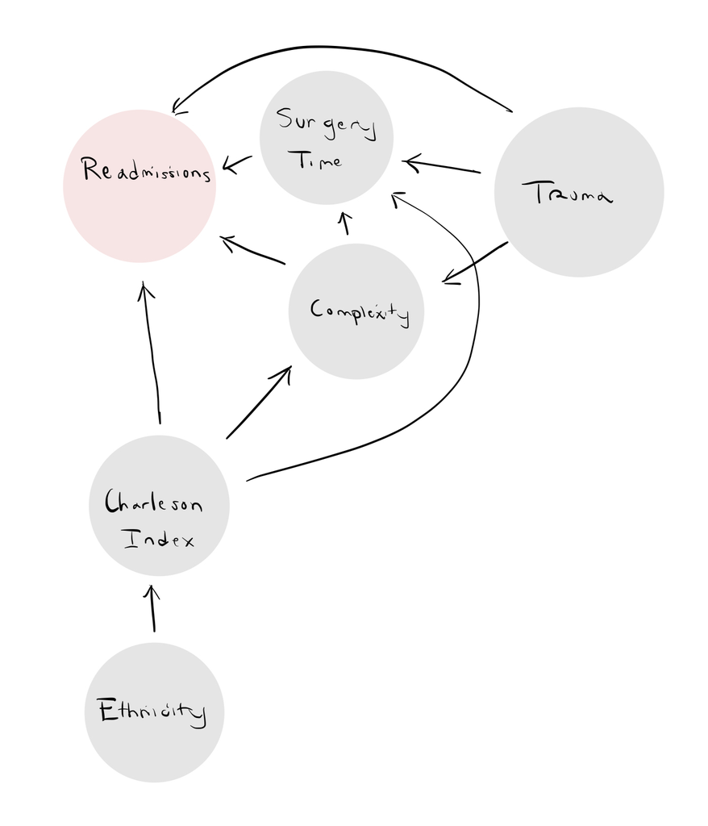

#### Bivariate / Faceted Plots

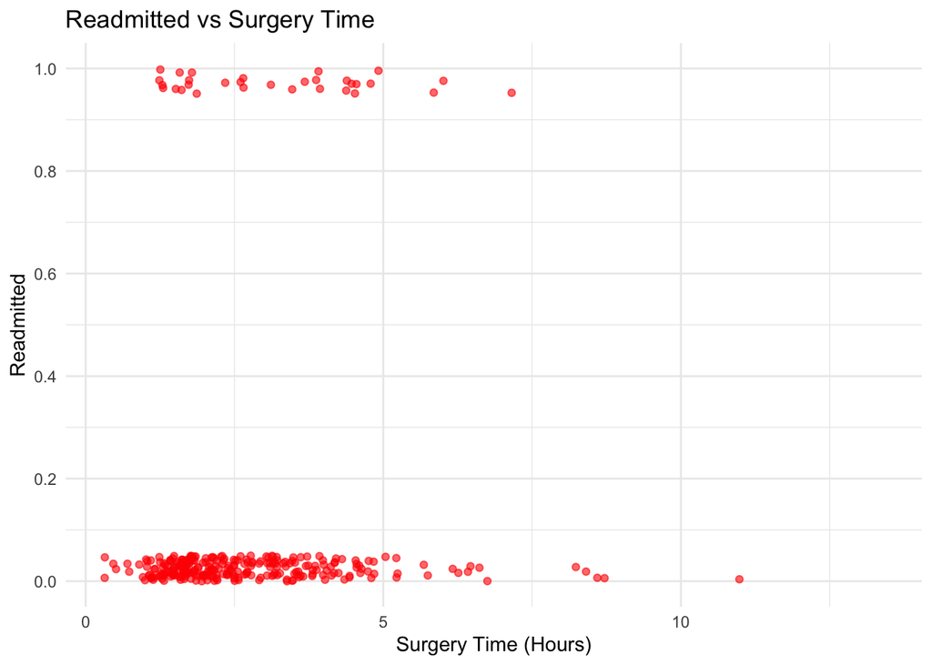

```r
ggplot(spinal_surg, aes(x = Surgery_Time, y = Readmitted)) +
  geom_jitter(height = 0.05, alpha = 0.6, color = "red") +
  labs(title = "Readmitted vs Surgery Time",
       x = "Surgery Time (Hours)",
       y = "Readmitted") +
  scale_y_continuous(limits = c(0, 1), breaks = seq(0, 1, by = 0.2)) +
  theme_minimal()
```

- There are many more none re-admitted observations compared to re-admitted observations
- There seems to be quite a spread of surgery times for none re-admission between 0.5 to 5 hours, then there are less after 5 hours
- There might be a chance that the mean surgery time mean for re-admitted observations is higher than none re-admitted observations, but we need more re-admitted observations to make that conclusion
- We will need to adjust for confounding

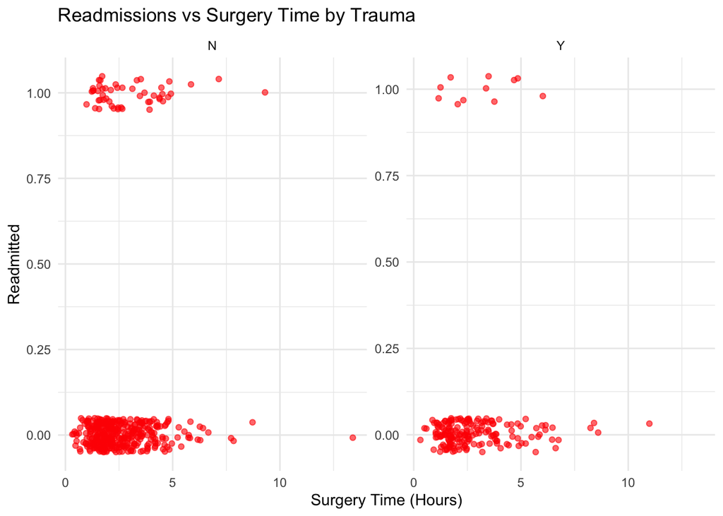

```r
ggplot(spinal_surg, aes(x = Surgery_Time, y = Readmitted)) +
  geom_jitter(height = 0.05, alpha = 0.6, color = "red") +
  labs(title = "Readmissions vs Surgery Time by Trauma",
       x = "Surgery Time (Hours)",
       y = "Readmitted") +
  facet_wrap(~ Trauma, ncol = 2, scales = "free_y") +
  theme_minimal()
```

- Surgerys where there is trauma appear to have a higher surgery time
- Hmmm unsure whether this conclusion is too good

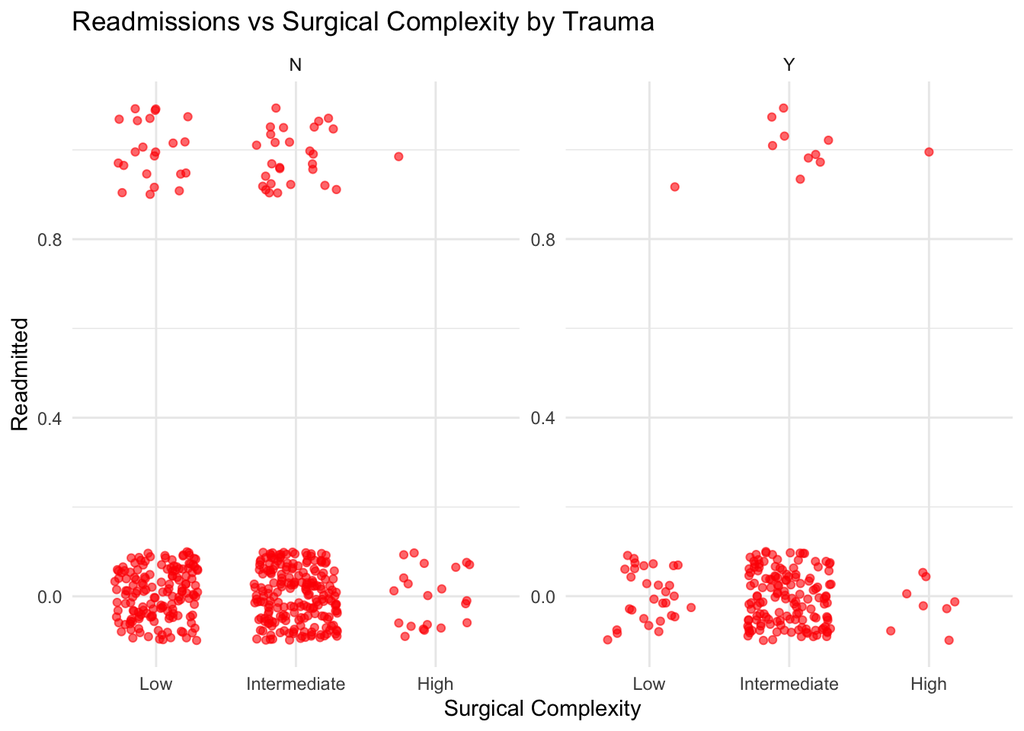

```r
ggplot(spinal_surg, aes(x = Surgical_Complexity, y = Readmitted)) +
  geom_jitter(height = 0.1, width = 0.3, alpha = 0.6, color = "red") +
  labs(title = "Readmissions vs Surgical Complexity by Trauma",
       x = "Surgical Complexity",
       y = "Readmitted") +
  facet_wrap(~ Trauma, ncol = 2, scales = "free_y") +
  theme_minimal()
```

- For no trauma, there appears to be slightly more re-admissions for intermediate surgical complexity compared to low surgical complexity

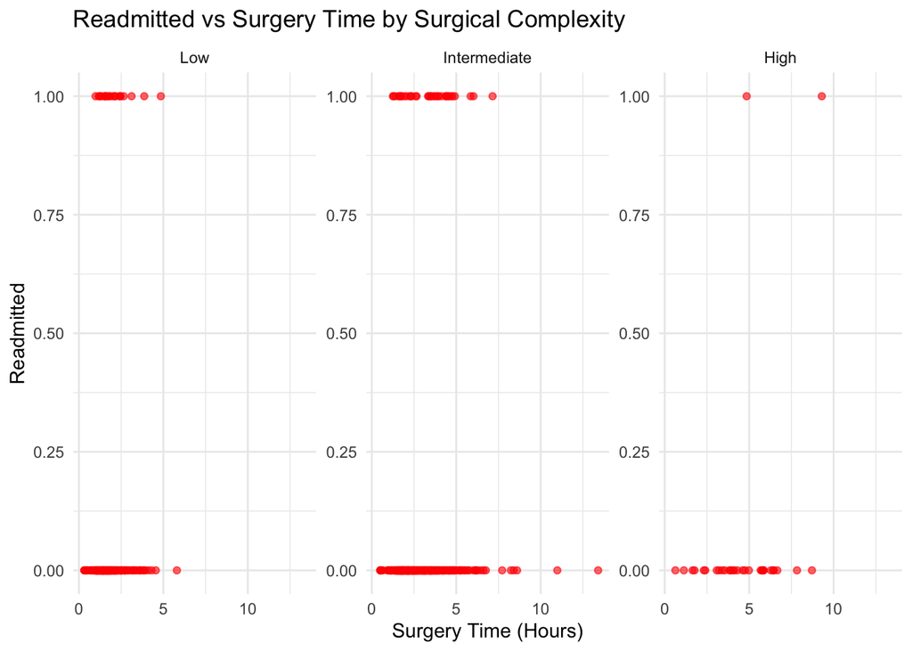

```r
ggplot(spinal_surg, aes(x = Surgery_Time, y = Readmitted)) +
  geom_point(alpha = 0.6, color = "red") +
  labs(title = "Readmitted vs Surgery Time by Surgical Complexity",
       x = "Surgery Time (Hours)",
       y = "Readmitted") +
  facet_wrap(~ Surgical_Complexity, scales = "free_y") +
  theme_minimal()
```

*Approximate mean of surgery time for re-admission and no re-admission observations appear to increase with increasing surgery complexity.* There seems to be much more intermediate complexity surgical procedures (we can make this observation elseware)

### Modelling

#### Initial Modelling

Fit appropriate generalised linear models to estimate the relative risk, risk difference and odds ratio of readmission within 30 days due to an increase in surgery time of 1 hour. Within the assumptions regarding confounding mentioned above, you must determine what are appropriate generalised linear models.

https://www.ncbi.nlm.nih.gov/pmc/articles/PMC4984606/

##### Logistic Regression

I used logistic regression with binomial and logit link, as it’s a model for the log odds.

```r
readmissions_logistic_model <- glm(Readmitted ~ Surgery_Time + Surgical_Complexity + Trauma + Charlson_Index + Ethnicity - 1, data = spinal_surg, family = binomial(link = "logit"))
readmissions_logistic_model_summary <- summary(readmissions_logistic_model)
readmissions_logistic_model_summary
```

```
##
## Call:
## glm(formula = Readmitted ~ Surgery_Time + Surgical_Complexity +
##     Trauma + Charlson_Index + Ethnicity - 1, family = binomial(link = "logit"),
##     data = spinal_surg)
##
## Deviance Residuals:
##     Min       1Q   Median       3Q      Max
## -1.1558  -0.4911  -0.4230  -0.3056   2.6799
##
## Coefficients:
##                                 Estimate Std. Error z value Pr(>|z|)
## Surgery_Time                     0.20573    0.08888   2.315 0.020633 *
## Surgical_ComplexityLow          -2.80969    0.57536  -4.883 1.04e-06 ***
## Surgical_ComplexityIntermediate -3.05065    0.59939  -5.090 3.59e-07 ***
## Surgical_ComplexityHigh         -3.92284    1.04258  -3.763 0.000168 ***
## TraumaY                         -0.86563    0.37121  -2.332 0.019705 *
## Charlson_Index6-12              -0.15616    0.78934  -0.198 0.843169
## EthnicityEuropean/other          0.24272    0.55783   0.435 0.663476
## EthnicityMaaori                  0.85439    0.64582   1.323 0.185853
## EthnicityPasifika                0.84761    0.58895   1.439 0.150096
## ---
## Signif. codes:  0 '***' 0.001 '**' 0.01 '*' 0.05 '.' 0.1 ' ' 1
##
## (Dispersion parameter for binomial family taken to be 1)
##
##     Null deviance: 851.18  on 614  degrees of freedom
## Residual deviance: 380.64  on 605  degrees of freedom
## AIC: 398.64
##
## Number of Fisher Scoring iterations: 5
```

##### Relative Risk Regression

I used binomial with a log link, as it’s a model for the relative risk. I supplied initial conditions for the algorithm, which I believe are appropriate. The algorithm converged.

```r
p <- ncol(model.matrix(readmissions_logistic_model))
readmissions_relative_risk_model <- glm(Readmitted ~ Surgery_Time + Surgical_Complexity + Trauma + Charlson_Index + Ethnicity - 1, data = spinal_surg, family = binomial(link = "log"), start = c(-1, rep(-1, p - 1)),  control = list(maxit=100000))
readmissions_relative_risk_model_summary <- summary(readmissions_relative_risk_model)
readmissions_relative_risk_model_summary
```

```
##
## Call:
## glm(formula = Readmitted ~ Surgery_Time + Surgical_Complexity +
##     Trauma + Charlson_Index + Ethnicity - 1, family = binomial(link = "log"),
##     data = spinal_surg, start = c(-1, rep(-1, p - 1)), control = list(maxit = 1e+05))
##
## Deviance Residuals:
##     Min       1Q   Median       3Q      Max
## -1.1674  -0.4814  -0.4245  -0.3083   2.6553
##
## Coefficients:
##                                 Estimate Std. Error z value Pr(>|z|)
## Surgery_Time                     0.15408    0.06608   2.332   0.0197 *
## Surgical_ComplexityLow          -2.81023    0.52408  -5.362 8.22e-08 ***
## Surgical_ComplexityIntermediate -2.99700    0.53882  -5.562 2.66e-08 ***
## Surgical_ComplexityHigh         -3.64751    0.90378  -4.036 5.44e-05 ***
## TraumaY                         -0.79273    0.33859  -2.341   0.0192 *
## Charlson_Index6-12              -0.14910    0.71573  -0.208   0.8350
## EthnicityEuropean/other          0.22726    0.51658   0.440   0.6600
## EthnicityMaaori                  0.80872    0.58191   1.390   0.1646
## EthnicityPasifika                0.76095    0.53571   1.420   0.1555
## ---
## Signif. codes:  0 '***' 0.001 '**' 0.01 '*' 0.05 '.' 0.1 ' ' 1
##
## (Dispersion parameter for binomial family taken to be 1)
##
##     Null deviance:    Inf  on 614  degrees of freedom
## Residual deviance: 380.86  on 605  degrees of freedom
## AIC: 398.86
##
## Number of Fisher Scoring iterations: 11
```

##### Risk Difference Regression

```r
readmissions_risk_difference_model <- glm(Readmitted ~ Surgery_Time + Surgical_Complexity + Trauma + Charlson_Index + Ethnicity - 1, data = spinal_surg, family = binomial(link = "identity"), start = c(0, rep(0.1, p - 1)), control = list(maxit=100000))
readmissions_risk_difference_model_summary <- summary(readmissions_risk_difference_model)
readmissions_risk_difference_model_summary
```

```
##
## Call:
## glm(formula = Readmitted ~ Surgery_Time + Surgical_Complexity +
##     Trauma + Charlson_Index + Ethnicity - 1, family = binomial(link = "identity"),
##     data = spinal_surg, start = c(0, rep(0.1, p - 1)), control = list(maxit = 1e+05))
##
## Deviance Residuals:
##     Min       1Q   Median       3Q      Max
## -0.7836  -0.4915  -0.4408  -0.3497   2.6428
##
## Coefficients:
##                                  Estimate Std. Error z value Pr(>|z|)
## Surgery_Time                     0.015378   0.008413   1.828   0.0676 .
## Surgical_ComplexityLow           0.063249   0.038334   1.650   0.0990 .
## Surgical_ComplexityIntermediate  0.048770   0.040158   1.214   0.2246
## Surgical_ComplexityHigh          0.009817   0.044032   0.223   0.8236
## TraumaY                         -0.044731   0.022942  -1.950   0.0512 .
## Charlson_Index6-12              -0.022945   0.048039  -0.478   0.6329
## EthnicityEuropean/other          0.009541   0.031849   0.300   0.7645
## EthnicityMaaori                  0.033218   0.044113   0.753   0.4514
## EthnicityPasifika                0.066337   0.044919   1.477   0.1397
## ---
## Signif. codes:  0 '***' 0.001 '**' 0.01 '*' 0.05 '.' 0.1 ' ' 1
##
## (Dispersion parameter for binomial family taken to be 1)
##
##     Null deviance:    Inf  on 614  degrees of freedom
## Residual deviance: 383.11  on 605  degrees of freedom
## AIC: 401.11
##
## Number of Fisher Scoring iterations: 32
```

#### Is there evidence that any one of these estimates differs by Trauma level?

We used Trauma as an interaction term for only Surgery Time to determine if there’s evidence that the Surgery Time estimates differ by Trauma level. We only interacted Trauma with Surgery Time as Surgery Time is our main covariate of interest. The exact same models from Part 3 were used for comparison, including the interaction terms, and extra parameters in the starting conditions were accounted for.

We can rely on the p-values for the interaction coefficient terms to make conclusions if estimates for Surgery Time differ by Trauma level.

##### Logistic Regression with Interaction

```r
readmissions_logistic_trauma_interaction_model <- glm(Readmitted ~ Trauma*Surgery_Time + Surgical_Complexity + Charlson_Index + Ethnicity - 1, data = spinal_surg, family = binomial(link = "logit"))
readmissions_logistic_trauma_interaction_model_summary <- summary(readmissions_logistic_trauma_interaction_model)
readmissions_logistic_trauma_interaction_model_summary
```

```
##
## Call:
## glm(formula = Readmitted ~ Trauma * Surgery_Time + Surgical_Complexity +
##     Charlson_Index + Ethnicity - 1, family = binomial(link = "logit"),
##     data = spinal_surg)
##
## Deviance Residuals:
##     Min       1Q   Median       3Q      Max
## -1.2853  -0.4890  -0.4189  -0.3099   2.6430
##
## Coefficients:
##                                 Estimate Std. Error z value Pr(>|z|)
## TraumaN                          -2.8838     0.5927  -4.865 1.14e-06 ***
## TraumaY                          -3.4344     0.8002  -4.292 1.77e-05 ***
## Surgery_Time                      0.2348     0.1041   2.255   0.0241 *
## Surgical_ComplexityIntermediate  -0.2564     0.3151  -0.814   0.4158
## Surgical_ComplexityHigh          -1.1692     0.8788  -1.331   0.1834
## Charlson_Index6-12               -0.1651     0.7924  -0.208   0.8350
## EthnicityEuropean/other           0.2442     0.5579   0.438   0.6616
## EthnicityMaaori                   0.8732     0.6463   1.351   0.1767
## EthnicityPasifika                 0.8474     0.5892   1.438   0.1504
## TraumaY:Surgery_Time             -0.1014     0.1892  -0.536   0.5921
## ---
## Signif. codes:  0 '***' 0.001 '**' 0.01 '*' 0.05 '.' 0.1 ' ' 1
##
## (Dispersion parameter for binomial family taken to be 1)
##
##     Null deviance: 851.18  on 614  degrees of freedom
## Residual deviance: 380.34  on 604  degrees of freedom
## AIC: 400.34
##
## Number of Fisher Scoring iterations: 5
```

Large p-values of 0.5921 for TraumaY:Surgery_Time indicate there is insignificant evidence to suggest that estimates for Surgery Time differs by Trauma level for logistic regression model.

##### Relative Risk Regression with Interaction

```r
p_interaction <- ncol(model.matrix(readmissions_logistic_trauma_interaction_model))
readmissions_relative_risk_interaction_model <- glm(Readmitted ~ Trauma*Surgery_Time + Surgical_Complexity + Charlson_Index + Ethnicity - 1, data = spinal_surg, family = binomial(link = "log"), start = c(-1, rep(-1, p_interaction - 1)),  control = list(maxit=100000))
readmissions_relative_risk_interaction_model_summary <- summary(readmissions_relative_risk_interaction_model)
readmissions_relative_risk_interaction_model_summary
```

```
##
## Call:
## glm(formula = Readmitted ~ Trauma * Surgery_Time + Surgical_Complexity +
##     Charlson_Index + Ethnicity - 1, family = binomial(link = "log"),
##     data = spinal_surg, start = c(-1, rep(-1, p_interaction -
##         1)), control = list(maxit = 1e+05))
##
## Deviance Residuals:
##     Min       1Q   Median       3Q      Max
## -1.2193  -0.4835  -0.4235  -0.3088   2.6334
##
## Coefficients:
##                                 Estimate Std. Error z value Pr(>|z|)
## TraumaN                         -2.82998    0.53023  -5.337 9.44e-08 ***
## TraumaY                         -3.47514    0.74374  -4.673 2.98e-06 ***
## Surgery_Time                     0.16013    0.07021   2.281   0.0226 *
## Surgical_ComplexityIntermediate -0.18866    0.27139  -0.695   0.4870
## Surgical_ComplexityHigh         -0.83558    0.74051  -1.128   0.2592
## Charlson_Index6-12              -0.15102    0.71672  -0.211   0.8331
## EthnicityEuropean/other          0.22762    0.51663   0.441   0.6595
## EthnicityMaaori                  0.81782    0.58244   1.404   0.1603
## EthnicityPasifika                0.76339    0.53569   1.425   0.1541
## TraumaY:Surgery_Time            -0.04573    0.16352  -0.280   0.7797
## ---
## Signif. codes:  0 '***' 0.001 '**' 0.01 '*' 0.05 '.' 0.1 ' ' 1
##
## (Dispersion parameter for binomial family taken to be 1)
##
##     Null deviance:    Inf  on 614  degrees of freedom
## Residual deviance: 380.77  on 604  degrees of freedom
## AIC: 400.77
##
## Number of Fisher Scoring iterations: 15
```

Large p-values of 0.7797 for TraumaY:Surgery_Time indicate there is insignificant evidence to suggest that estimates for Surgery Time differs by Trauma level for relative risk model.

##### Risk Difference Regression with Interaction

```r
readmissions_risk_difference_interaction_model <- glm(Readmitted ~ Trauma*Surgery_Time + Surgical_Complexity + Trauma + Charlson_Index + Ethnicity - 1, data = spinal_surg, family = binomial(link = "identity"), start = c(0.03, rep(0.03, p_interaction - 1)), control = list(maxit=100000))
readmissions_risk_difference_interaction_model_summary <- summary(readmissions_risk_difference_interaction_model)
readmissions_risk_difference_interaction_model_summary
```

```
##
## Call:
## glm(formula = Readmitted ~ Trauma * Surgery_Time + Surgical_Complexity +
##     Trauma + Charlson_Index + Ethnicity - 1, family = binomial(link = "identity"),
##     data = spinal_surg, start = c(0.03, rep(0.03, p_interaction -
##         1)), control = list(maxit = 1e+05))
##
## Deviance Residuals:
##     Min       1Q   Median       3Q      Max
## -0.9239  -0.5032  -0.4272  -0.3433   2.6188
##
## Coefficients:
##                                 Estimate Std. Error z value Pr(>|z|)
## TraumaN                          0.04324    0.03659   1.182   0.2372
## TraumaY                          0.04261    0.04306   0.989   0.3225
## Surgery_Time                     0.02330    0.01142   2.040   0.0414 *
## Surgical_ComplexityIntermediate -0.02080    0.02740  -0.759   0.4477
## Surgical_ComplexityHigh         -0.06560    0.02869  -2.287   0.0222 *
## Charlson_Index6-12              -0.02280    0.04443  -0.513   0.6078
## EthnicityEuropean/other          0.01280    0.02447   0.523   0.6010
## EthnicityMaaori                  0.04937    0.04080   1.210   0.2263
## EthnicityPasifika                0.06977    0.04085   1.708   0.0876 .
## TraumaY:Surgery_Time            -0.01711    0.01445  -1.184   0.2362
## ---
## Signif. codes:  0 '***' 0.001 '**' 0.01 '*' 0.05 '.' 0.1 ' ' 1
##
## (Dispersion parameter for binomial family taken to be 1)
##
##     Null deviance:    Inf  on 614  degrees of freedom
## Residual deviance: 382.22  on 604  degrees of freedom
## AIC: 402.22
##
## Number of Fisher Scoring iterations: 41
```

#### Other Relative Risk Regression Estimators

For the relative risk model; the constraint X*beta <= 0 is active, observations close to X*beta = 0 are extremely influential. At the boundary, beta_hat does not solve the score equations and does not have an approximately Normal distribution. As seen in the exploratory analysis, there are numerous outlier observations: this is a problem we should probably deal with by choosing different estimators for a relative risk estimate.

We do not get reliable standard error estimates, as the models are incorrect, and the standard errors relys on correctly specified variance functions. Instead we can use the sandwich estimator for the standard errors as it is agnostic to the model.

##### Non-linear Least Squares Working Model

We used Gaussian (normal) family with log link.

```r
p <- ncol(model.matrix(readmissions_relative_risk_model))
readmissions_relative_risk_non_linear_least_squares_model <- glm(Readmitted ~ Surgery_Time + Surgical_Complexity + Trauma + Charlson_Index + Ethnicity - 1, data = spinal_surg, family = gaussian(link = "log"), start = c(-1, rep(0, p - 1)),  control = list(maxit=10000))
readmissions_relative_risk_non_linear_least_squares_model_summary <- summary(readmissions_relative_risk_non_linear_least_squares_model)
readmissions_relative_risk_non_linear_least_squares_model_summary
```

```
##
## Call:
## glm(formula = Readmitted ~ Surgery_Time + Surgical_Complexity +
##     Trauma + Charlson_Index + Ethnicity - 1, family = gaussian(link = "log"),
##     data = spinal_surg, start = c(-1, rep(0, p - 1)), control = list(maxit = 10000))
##
## Deviance Residuals:
##      Min        1Q    Median        3Q       Max
## -0.45068  -0.10550  -0.08169  -0.03465   0.98017
##
## Coefficients:
##                                 Estimate Std. Error t value Pr(>|t|)
## Surgery_Time                     0.14992    0.05075   2.954 0.003256 **
## Surgical_ComplexityLow          -2.91821    0.67774  -4.306 1.94e-05 ***
## Surgical_ComplexityIntermediate -3.13086    0.68724  -4.556 6.32e-06 ***
## Surgical_ComplexityHigh         -3.20024    0.83987  -3.810 0.000153 ***
## TraumaY                         -1.04710    0.41986  -2.494 0.012899 *
## Charlson_Index6-12              -0.71763    1.03077  -0.696 0.486565
## EthnicityEuropean/other          0.32493    0.68534   0.474 0.635588
## EthnicityMaaori                  1.17200    0.69654   1.683 0.092968 .
## EthnicityPasifika                0.87514    0.68479   1.278 0.201748
## ---
## Signif. codes:  0 '***' 0.001 '**' 0.01 '*' 0.05 '.' 0.1 ' ' 1
##
## (Dispersion parameter for gaussian family taken to be 0.08791316)
##
##     Null deviance: 553.000  on 614  degrees of freedom
## Residual deviance:  53.187  on 605  degrees of freedom
## AIC: 260.5
##
## Number of Fisher Scoring iterations: 13
```

##### Poisson Working Model

We used Poisson family with log link.

```r
readmissions_relative_risk_poisson_working_model <- glm(Readmitted ~ Surgery_Time + Surgical_Complexity + Trauma + Charlson_Index + Ethnicity - 1, data = spinal_surg, family = poisson(link = "log"), start = c(-1, rep(0, p - 1)),  control = list(maxit=10000))
readmissions_relative_risk_poisson_working_model_summary <- summary(readmissions_relative_risk_poisson_working_model)
readmissions_relative_risk_poisson_working_model_summary
```

```
##
## Call:
## glm(formula = Readmitted ~ Surgery_Time + Surgical_Complexity +
##     Trauma + Charlson_Index + Ethnicity - 1, family = poisson(link = "log"),
##     data = spinal_surg, start = c(-1, rep(0, p - 1)), control = list(maxit = 10000))
##
## Deviance Residuals:
##     Min       1Q   Median       3Q      Max
## -1.0916  -0.4726  -0.4132  -0.3067   2.2625
##
## Coefficients:
##                                 Estimate Std. Error z value Pr(>|z|)
## Surgery_Time                     0.17189    0.07521   2.286   0.0223 *
## Surgical_ComplexityLow          -2.84278    0.54792  -5.188 2.12e-07 ***
## Surgical_ComplexityIntermediate -3.04722    0.56615  -5.382 7.35e-08 ***
## Surgical_ComplexityHigh         -3.81119    0.97616  -3.904 9.45e-05 ***
## TraumaY                         -0.77800    0.35344  -2.201   0.0277 *
## Charlson_Index6-12              -0.12673    0.74845  -0.169   0.8655
## EthnicityEuropean/other          0.22613    0.53640   0.422   0.6733
## EthnicityMaaori                  0.77302    0.61402   1.259   0.2080
## EthnicityPasifika                0.75610    0.56116   1.347   0.1779
## ---
## Signif. codes:  0 '***' 0.001 '**' 0.01 '*' 0.05 '.' 0.1 ' ' 1
##
## (Dispersion parameter for poisson family taken to be 1)
##
##     Null deviance: 1106.00  on 614  degrees of freedom
## Residual deviance:  266.77  on 605  degrees of freedom
## AIC: 406.77
##
## Number of Fisher Scoring iterations: 14
```

##### Gamma Model

```r
readmissions_relative_gamma_working_model <- glm(Readmitted ~ Surgery_Time + Surgical_Complexity + Trauma + Charlson_Index + Ethnicity - 1, data = spinal_surg, family = quasi(link = "log", variance = "mu^2"), start = c(0.1, rep(0.1, p - 1)),  control = list(maxit=100000))
readmissions_relative_gamma_working_model_summary <- summary(readmissions_relative_gamma_working_model)
readmissions_relative_gamma_working_model_summary
```

```
##
## Call:
## glm(formula = Readmitted ~ Surgery_Time + Surgical_Complexity +
##     Trauma + Charlson_Index + Ethnicity - 1, family = quasi(link = "log",
##     variance = "mu^2"), data = spinal_surg, start = c(0.1, rep(0.1,
##     p - 1)), control = list(maxit = 1e+05))
##
## Deviance Residuals:
##    Min      1Q  Median      3Q     Max
##  0.000   0.000   0.000   0.000   6.956
##
## Coefficients:
##                                 Estimate Std. Error t value Pr(>|t|)
## Surgery_Time                      0.2157     0.1035   2.085   0.0375 *
## Surgical_ComplexityLow           -2.9239     0.5155  -5.671 2.20e-08 ***
## Surgical_ComplexityIntermediate  -3.1652     0.5423  -5.836 8.71e-09 ***
## Surgical_ComplexityHigh          -4.3917     0.8950  -4.907 1.19e-06 ***
## TraumaY                          -0.5566     0.3242  -1.717   0.0865 .
## Charlson_Index6-12               -0.1774     0.7577  -0.234   0.8150
## EthnicityEuropean/other           0.1740     0.4746   0.367   0.7140
## EthnicityMaaori                   0.6665     0.5976   1.115   0.2652
## EthnicityPasifika                 0.7151     0.5518   1.296   0.1955
## ---
## Signif. codes:  0 '***' 0.001 '**' 0.01 '*' 0.05 '.' 0.1 ' ' 1
##
## (Dispersion parameter for quasi family taken to be 12.15633)
##
##     Null deviance:   0.00  on 614  degrees of freedom
## Residual deviance: 838.77  on 605  degrees of freedom
## AIC: NA
##
## Number of Fisher Scoring iterations: 27
```

##### Comparing Standard Errors

First compute the standard errors for Surgery Time using vCovHC from the sandwich package.

```r
standard_error_comparison <- rbind(c(tidy(readmissions_relative_risk_model)$estimate[1], tidy(readmissions_relative_risk_model)$std.error[1]), c(tidy(readmissions_relative_risk_non_linear_least_squares_model)$estimate[1], sqrt(diag(vcovHC(readmissions_relative_risk_non_linear_least_squares_model, type = "HC2")))[1]), c(tidy(readmissions_relative_risk_poisson_working_model)$estimate[1], sqrt(diag(vcovHC(readmissions_relative_risk_poisson_working_model, type = "HC2")))[1]), c(tidy(readmissions_relative_gamma_working_model)$estimate[1], sqrt(diag(vcovHC(readmissions_relative_gamma_working_model, type = "HC2")))[1]))

rownames(standard_error_comparison) <- rbind("Relative Risk Model", "Non-Linear Least Squares Working Model", "Poisson Working Model", "Gamma Working Model")
colnames(standard_error_comparison) <- c("Estimates", "Std. Error")
standard_error_comparison
```

```
##                                        Estimates Std. Error
## Relative Risk Model                    0.1540805 0.06607771
## Non-Linear Least Squares Working Model 0.1499202 0.09633687
## Poisson Working Model                  0.1718879 0.06998969
## Gamma Working Model                    0.2157139 0.08278528
```

We have (slight) underestimates our standard error (and variance) for the relative risk model.

### Discussion

- What I attempted / didn’t
- Convergence vs non convergence
- Lack of data for some factors
- Trauma surgery, they might look after you more, less likely to get readmitted. Those without obvious trauma might get treated with less priority, hence readmitted

Notes - How do we converge Risk Difference, Angeline to talk to Alain. What is the risk difference?